# Analiza reprodukowalności artykułu opisującego pakier stplanr

Paweł Koźmiński, Konrad Welkier

3/9/2020

# Wczytanie potrzebnych pakietów

Na potrzeby analizy reprodukowalności artykułu zainstalowaliśmy oraz załadowaliśmy ponad 30 pakietów znajdujących się w archiwum CRAN. Były to: sp, rgeos, rgdal, sf, SpatialEpi, diseasemapping, leaflet, tmap, mapview, mapmisc, XML, twitteR, ggplot2, muStat, mgcv, shiny, haven, rio, dplyr, osmdata, stats19, stplanr, nycflights13, cyclestreets, igraph, Rcpp, aspace, MCI oraz nieliczne zależności. Co ciekawe, nie wymieniono tam pakietów użytych w załączonym pliku .R, takich jak knitr czy readr.  
Testy były wykonywane na linuxowej wersji R 3.6.3. W tym wydaniu nie ma dostępnych pakietów nycflights (jest nycflights13) oraz bikedata, które również były wymienione jako używane. Warto w tym miejscu dodać, że wersja środowiska R nie została umiejscowiona w żadnym miejscu artykułu.  
Oczywiście najważniejszym momentem było wczytanie pakietu stplanr:

```r
library(stplanr)
```

# Sprawdzenie funkcji pakietu stplanr

Tabela nr 1 w artykule przedstawia funkcje type `OD_`, `line_`, `route_` znajdujące sie w opisywanym pakiecie. Co ciekawe, wywołanie wypisania wszystkich funkcji pakietu, wypisuje znacznie więcej opcji, także tych znajdujących się w powyższych klasach:

```r
f <- lsf.str("package:stplanr")
length(f)
```

```
## [1] 100
```

```r
c(f[grepl("od_", as.vector(f))], f[grepl("line_", as.vector(f))], f[grepl("route_", as.vector(f))])
```

```
##  [1] "od_aggregate"              "od_aggregate_from"
##  [3] "od_aggregate_to"           "od_coords"
##  [5] "od_coords2line"            "od_dist"
##  [7] "od_id_character"           "od_id_max_min"
##  [9] "od_id_order"               "od_id_szudzik"
## [11] "od_oneway"                 "od_radiation"
## [13] "od_to_odmatrix"            "line_bearing"
## [15] "line_length"               "line_match"
## [17] "line_midpoint"             "line_sample"
## [19] "line_segment"              "line_via"
## [21] "overline_intersection"     "update_line_geometry"
## [23] "route_cyclestreets"        "route_dodgr"
## [25] "route_graphhopper"         "route_local"
## [27] "route_nearest_point"       "route_split"
## [29] "route_split_id"            "route_transportapi_public"
```

# Wczytanie danych

Niespodziewanie, sprawdzenie już jednej z pierwszych funkcjonalności pakietu stplanr skończyło się niepowodzeniem. Oprócz faktu, że dołączony plik lovelace.R zawiera odwołania do niewiadomego pliku “fun_table.csv”, zmieniła się prawdopodobnie struktura oraz sposób wykorzystania funkcji `dl_stats19()` - trzeba podać konkretny zbiór do pobrania, czego nie uwzględniono w artykule. W następnym kroku rekomendowano użycie funkcji z rodziny `read_stats19_`, które w aktualnej wersji pakietu, najprawdopodobniej nie istnieją. Celem wykonania dalszej części analizy, pobraliśmy przy pomocy funkcji `dl_stats19()` podobnie nazwany plik Stats19_Data_2005-2014.zip.  
## Kod z artykułu: `dl_stats19() # download and extract stats19 road traffic casualty data#>`  
`[1] "Data saved at: /tmp/RtmpppF3E2/Accidents0514.csv"#>`  
`[2] "Data saved at: /tmp/RtmpppF3E2/Casualties0514.csv"#>`  
`[3] "Data saved at: /tmp/RtmpppF3E2/Vehicles0514.csv"`  
`ac <- read_stats19_ac()`  
`ca <- read_stats19_ca()`  
`ve <- read_stats19_ve()`  
## Nasza wersja:

```r
library(stats19)
ac <- read.csv("/tmp/RtmpsoxDP9/Stats19_Data_2005-2014/Accidents0514.csv")
ca <- read.csv("/tmp/RtmpsoxDP9/Stats19_Data_2005-2014/Casualties0514.csv")
# ramka ve nie jest później wykorzystywana
```

# Obróbka ramek danych - kolejny problem?

Podczas jednej z kolejnych funkcji na ramkach danych napotkaliśmy na kolejny problem: kolumna `Casualty_Several` jest zmienną liczbową, brak w niej wartości “Fatal”:

```r
data("route_network")
# sp::proj4string(ca_sp) <- sp::proj4string(route_network)
bb <- bb2poly(route_network)
sp::proj4string(bb) <- sp::proj4string(route_network)
#ca_local <- ca_sp[bb,]

#Nadal błędy
```

W dalszej części kodu występuje jak najbardziej poprawne wczytanie danych, po którym występuje - o dziwo - nieodnaleziona funkcja `buff_geo()` z pakietu stplanr. Z tego powodu wykonanie także dalszej części kodu kończy się porażką.

```r
if(!file.exists("reqfiles.RData"))
  download.file("https://github.com/Robinlovelace/stplanr/raw/rjournal-responses/lovelace/reqfiles.RData", "reqfiles.RData", mode = "wb")
load("reqfiles.RData")
# rnet_buff_100 <- buff_geo(route_network, width = 100)
# ca_buff <- ca_local[rnet_buff_100,]
```

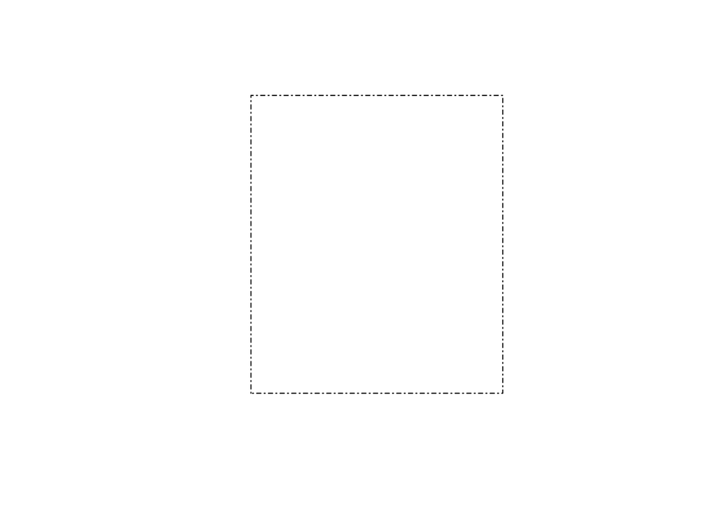

```r
bb <- bb2poly(route_network)
plot(bb, lty = 4)
```

```r
# plot(rnet_buff_100, col = "grey", add = TRUE)
# points(ca_local, pch = 4)
# points(ca_buff, cex = 3)
```

Niestety wykonanie pierwszego wykresu kończy się niepowodzeniem.

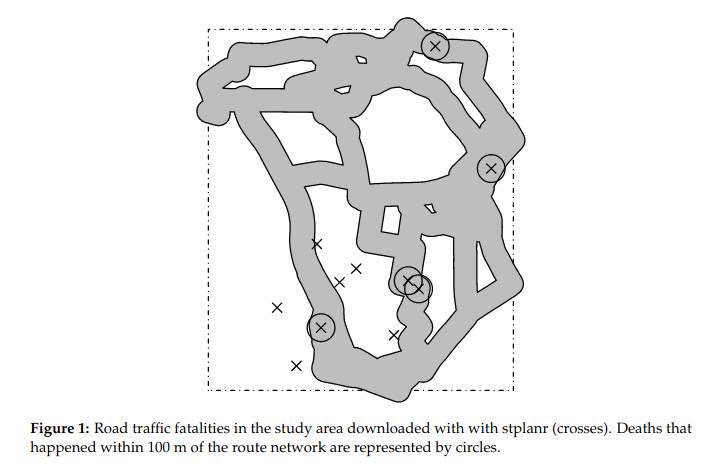

# Użycie poszczególnych funkcji

## od2line

```r
data("flow", package = "stplanr")
head(flow[c(1:3, 12)])
```

```
##        Area.of.residence Area.of.workplace All Bicycle
## 920573         E02002361         E02002361 109       2
## 920575         E02002361         E02002363  38       0
## 920578         E02002361         E02002367  10       0
## 920582         E02002361         E02002371  44       3
## 920587         E02002361         E02002377  34       0
## 920591         E02002361         E02002382   7       0
```

```r
data("cents", package = "stplanr")
as.data.frame(cents[1:3, -c(3,4)])
```

```
##       geo_code  MSOA11NM coords.x1 coords.x2
## 1708 E02002384 Leeds 055 -1.546463  53.80952
## 1712 E02002382 Leeds 053 -1.511861  53.81161
## 1805 E02002393 Leeds 064 -1.524205  53.80410
```

```r
l <- od2line(flow = flow, zones = cents)

airports_sf <- sf::st_as_sf(airports, coords = c("lon", "lat"), crs = 4326)
ny_buff <- geo_buffer(airports_sf[airports_sf$faa == "NYC",], dist = 1e6)
airports_near <- airports_sf[ny_buff,]
```

```
## although coordinates are longitude/latitude, st_intersects assumes that they are planar
## although coordinates are longitude/latitude, st_intersects assumes that they are planar
```

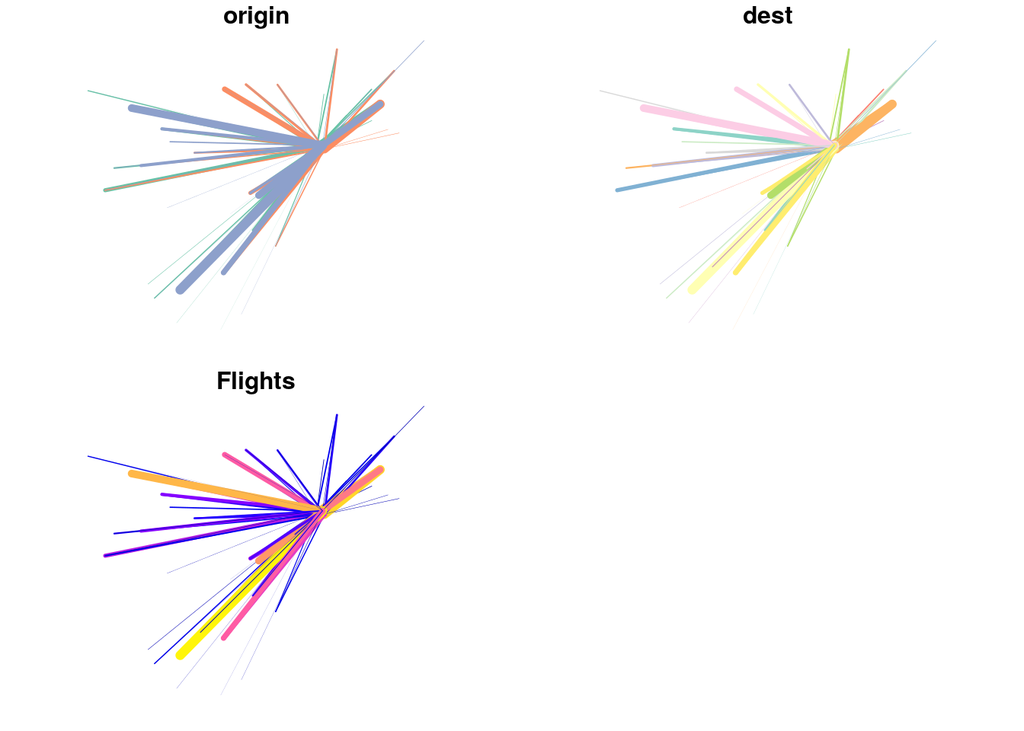

```r
flights_near <- flights[flights$dest %in% airports_near$faa,]
flights_agg <- dplyr::group_by(flights_near, origin, dest) %>%
  dplyr::summarise(Flights = n())
flights_sf = od2line(flow = flights_agg, zones = airports_near)
plot(flights_sf, lwd = flights_sf$Flights / 1e3)
```

```r
tmap_mode("view")
```

```
## tmap mode set to interactive viewing
```

[output not shown]

[interactive chart not shown]

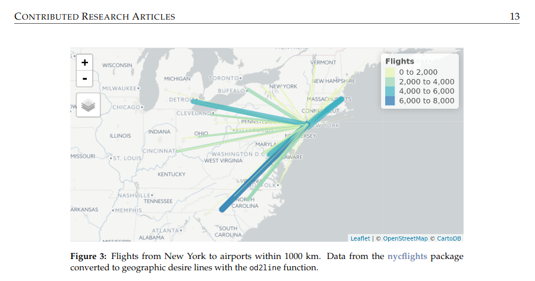

Fragment artykułu

```r
pal <- viridis::viridis(n = 3, option = "C")
tm_shape(flights_sf) +
  tm_lines(lwd = "Flights", col = "Flights", scale = 12, n = 3, palette = "YlGnBu")
```

## route network

```r
plot(route_network, lwd=0)
```

```r
# plot(l, lwd = l$All / 10, add = TRUE)
# Error in plot.xy(xy.coords(x, y), type = type, ...) : plot.new has not been called yet
# lines(routes_fast, col = "red")
routes_fast$All <- l$All
rnet <- overline(routes_fast, "All", fun = sum)
rnet$flow <- rnet$All / mean(rnet$All) * 3
```

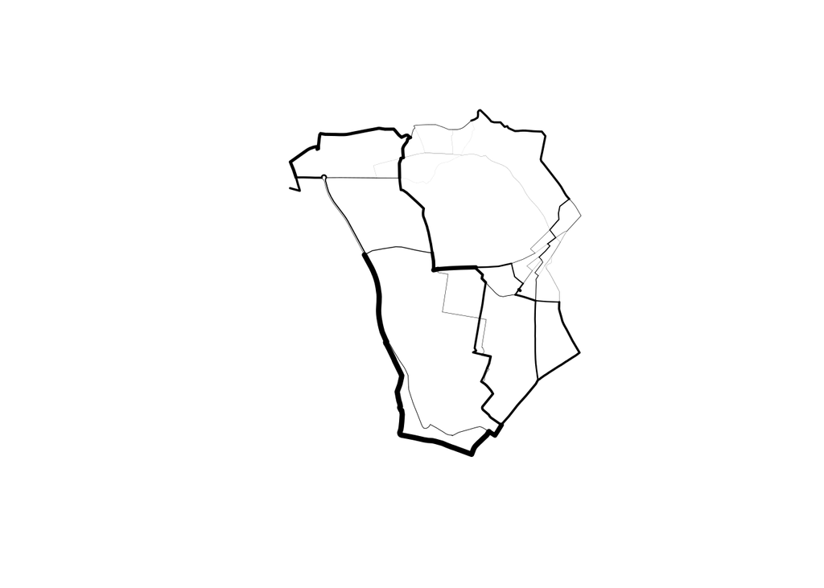

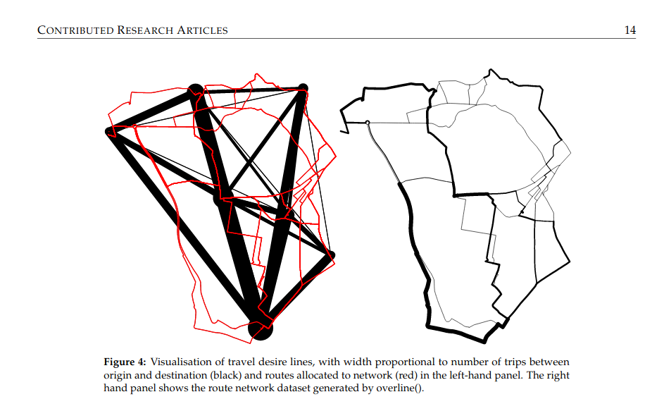

Fragment artykułu z mapą

```r
plot(rnet, lwd = rnet$flow / mean(rnet$flow))
```

## Fragment trudny do reprodukowania - wymagane API

`route examples (not run, needs api keys) --------------------------------`  
`route_bl <- route_cyclestreet(from = "Bradford, Yorkshire", to = "Leeds, Yorkshire")`  
`route_c1_c2 <- route_cyclestreet(cents[1,], cents[2,])`  
`route_bl_raw <- route_cyclestreet(from = "Bradford", to = "Leeds", save_raw = TRUE)`

A także następny fragment z użyciem `route_graphhopper()`

# Sytuacyjne plany miast

```r
data_dir <- system.file("extdata", package = "stplanr")
unzip(file.path(data_dir, 'smallsa1.zip'))
unzip(file.path(data_dir, 'testcycleway.zip'))
sa1income <- rgdal::readOGR(".", "smallsa1")
testcycleway <- rgdal::readOGR(".", "testcycleway")
file.remove(list.files(pattern = "^(smallsa1|testcycleway).*"))
```

```
## [1] TRUE TRUE TRUE TRUE TRUE TRUE TRUE TRUE TRUE
```

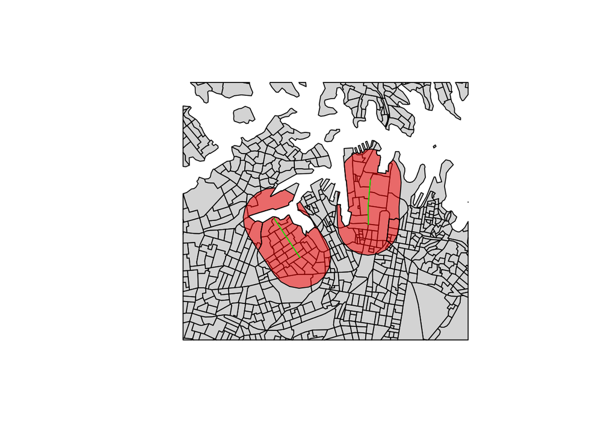

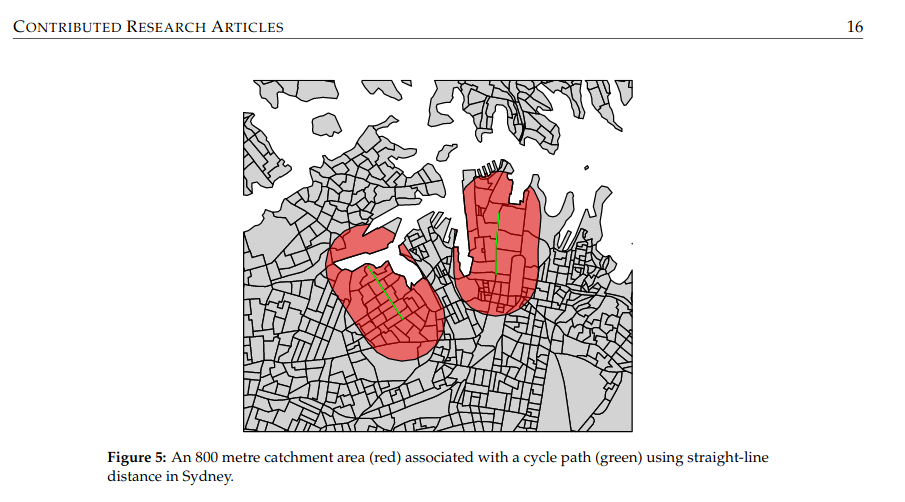

```r
catch800m <- calc_catchment(
  polygonlayer = sa1income,
  targetlayer = testcycleway,
  calccols = c('Total'),
  distance = 800,
  projection = 'austalbers',
  dissolve = TRUE
)

plot(sa1income, col = "light grey")
plot(catch800m, col = rgb(1, 0, 0, 0.5), add = TRUE)
plot(testcycleway, col = "green", add = TRUE)
```

```r
unzip(file.path(data_dir, 'sydroads.zip'))
sydroads <- rgdal::readOGR(".", "roads")
file.remove(list.files(pattern = "^(roads).*"))
```

```
## [1] TRUE TRUE TRUE TRUE TRUE
```

```r
sydnetwork <- SpatialLinesNetwork(sydroads)

netcatch800m <- calc_network_catchment(
  sln = sydnetwork,
  polygonlayer = sa1income,
  targetlayer = testcycleway,
  calccols = c('Total'),
  maximpedance = 800,
  distance = 100,
  projection = 'austalbers'
)
```

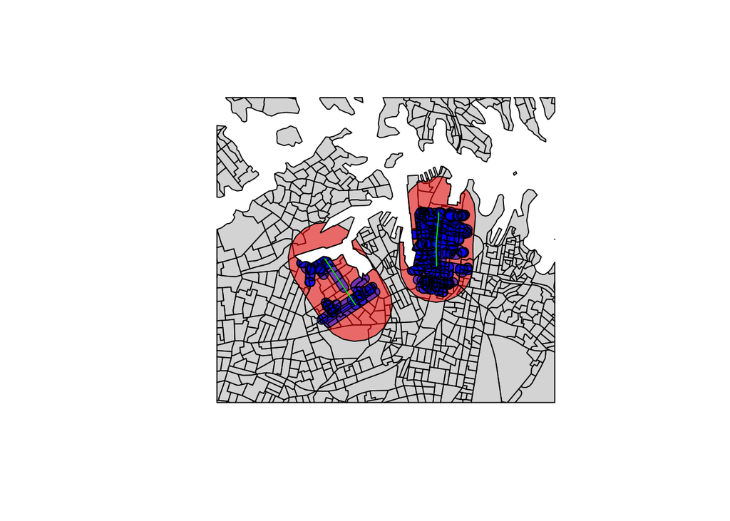

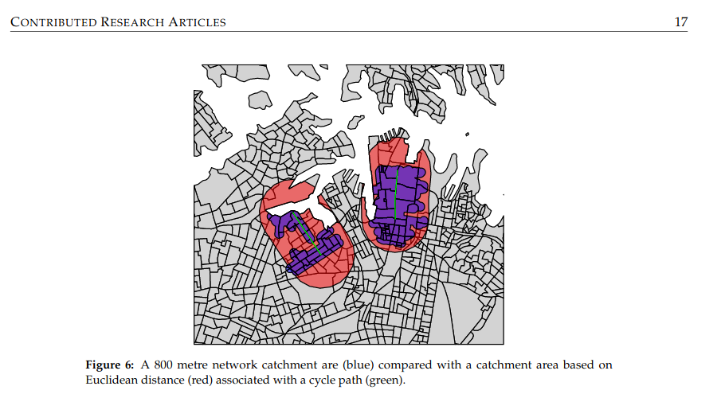

```r
plot(sa1income, col = "light grey")
plot(catch800m, col = rgb(1, 0, 0, 0.5), add = TRUE)
plot(netcatch800m, col = rgb(0, 0, 1, 0.5), add = TRUE)
plot(testcycleway, col = "green", add = TRUE)
```

# Modelowanie

```r
l$d_euclidean <- line_length(l)
```

```
## Transforming to CRS +proj=aeqd +lat_0=53.81907246 +lon_0=-1.52841182 +x_0=0 +y_0=0 +ellps=WGS84
```

```r
l$d_rf <- routes_fast$length
## routes_slow <- line2route(l, route_cyclestreet, plan = "quietest")
l$d_rq <- routes_slow$length # quietest route distance
Q <- mean(l$d_rf / l$d_euclidean, na.rm = TRUE)
QDF <- mean(l$d_rq / l$d_rf, na.rm = TRUE)
Q
```

```
## [1] 1.298767
```

```r
QDF
```

```
## [1] 1.034721
```

```r
(QDFt <- mean(routes_slow$time / routes_fast$time, na.rm = TRUE))
```

```
## [1] 1.052855
```

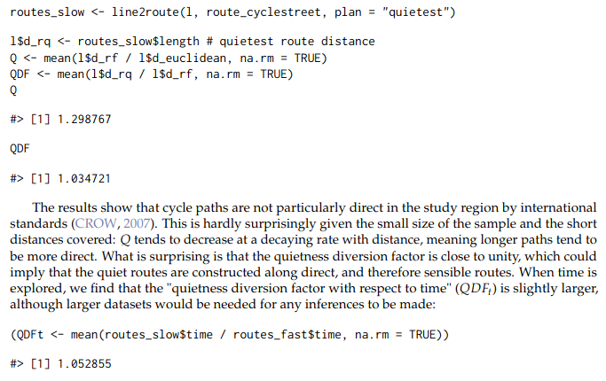

Poprawne obliczenia

# Wizualizacja

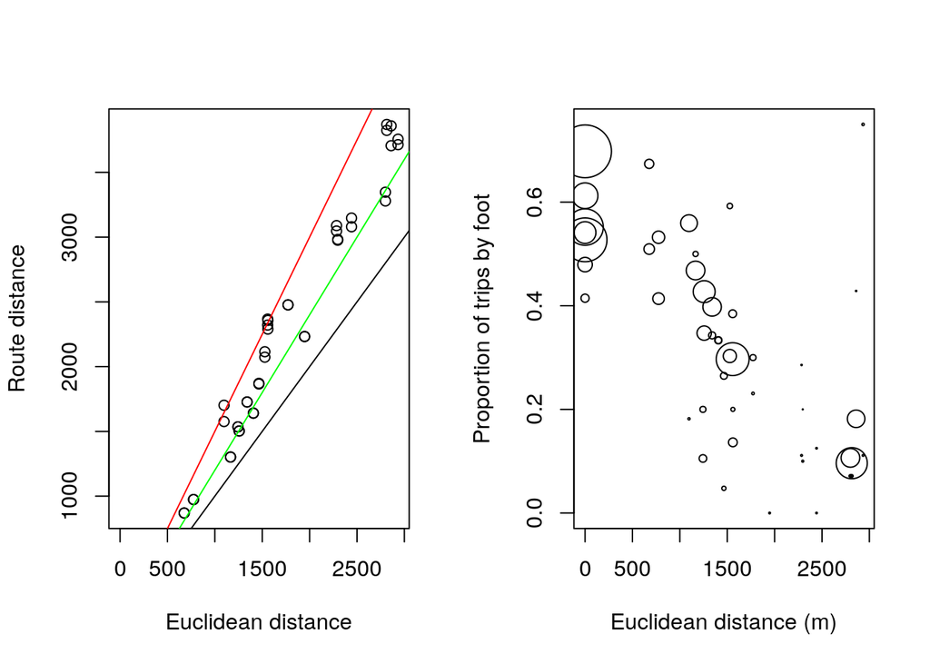

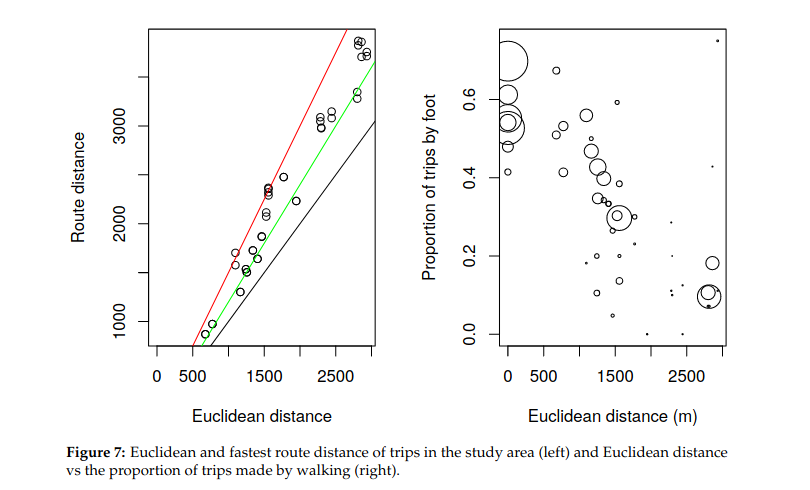

```r
par(mfrow = c(1, 2))
lgb <- sp::spTransform(l, CRSobj = CRS("+init=epsg:27700"))
l$d_euclidean <- rgeos::gLength(lgb, byid = T)
l$d_rf <- routes_fast@data$length
plot(l$d_euclidean, l$d_rf,
  xlab = "Euclidean distance", ylab = "Route distance")
abline(a = 0, b = 1)
abline(a = 0, b = 1.2, col = "green")
abline(a = 0, b = 1.5, col = "red")
l$pwalk <- l$On.foot / l$All
plot(l$d_euclidean, l$pwalk, cex = l$All / 50,
  xlab = "Euclidean distance (m)", ylab = "Proportion of trips by foot")
```

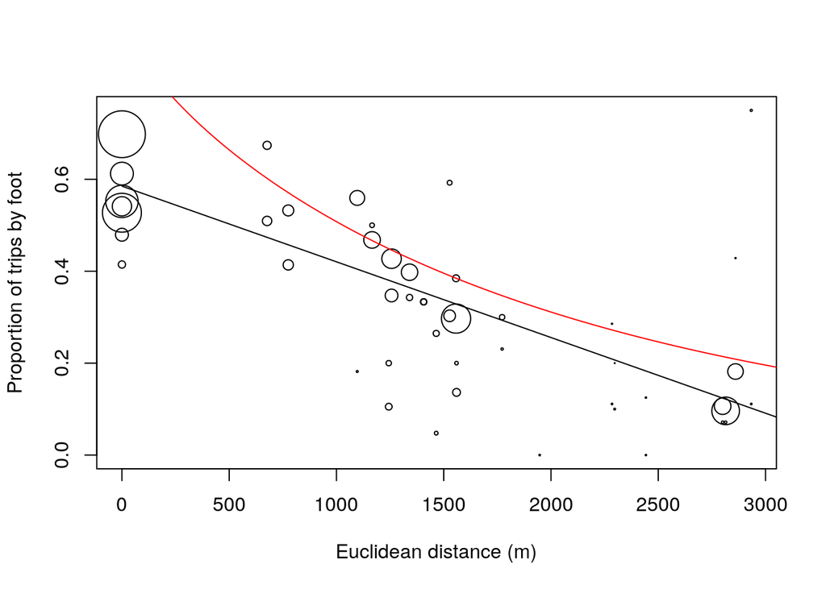

```r
lm1 <- lm(pwalk ~ d_euclidean, data = l@data, weights = All)
lm2 <- lm(pwalk ~ d_rf, data = l@data, weights = All)
lm3 <- glm(pwalk ~ d_rf + I(d_rf^0.5),
           data = l@data, weights = All, family = quasipoisson(link = "log"))

plot(l$d_euclidean, l$pwalk, cex = l$All / 50,
  xlab = "Euclidean distance (m)", ylab = "Proportion of trips by foot")
l2 <- data.frame(d_euclidean = 1:5000, d_rf = 1:5000)
lm1p <- predict(lm1, l2)
lm2p <- predict(lm2, l2)
lm3p <- predict(lm3, l2)
lines(l2$d_euclidean, lm1p)
lines(l2$d_euclidean, exp(lm2p), col = "green")
lines(l2$d_euclidean, exp(lm3p), col = "red")
```

# Podsumowanie

Słowem zakończenia, uważamy że, pomimo wstępnych problemów związanych z wczytaniem pakietów oraz danych, stopień reprodukowalności artykułu jest satysfakcjonujący. Być może, w trakcie rozwoju pakietu, niektóre funkcje zostały zmodyfikowane, co wywołało problemy, jednak funkcjonalność pakietu jest na tyle bogata i interesująca, a jednocześnie trudna do zrozumienia dla nowicjusza, że dobrze że praktycznie każdy użytkownik R może podążyć śladami twórców stplanr.